# Time Series: A First Course with Bootstrap Starter

# Lesson 9-1: Weak Dependence

- We can quantify serial dependence through the ACVF.
- Recall entropy mixing (Paradigm 8.2.11) as another measure of serial dependence.

## Example 9.1.1. Slow Polynomial Decay – Long Memory

- Suppose that a time series has ACVF $\gamma (h) = O({|h|}^{-a})$ for $0 < a \leq 1$.
- The notation means the ACVF is bounded by a constant times that rate.
- There is fairly slow decay in lag when $a$ is small: this means persistence, or high association, across large time lags. This is called *long-range dependence* or *long memory*.

## Exercise 9.2. Long-Range Dependence

- An example of long-range dependence is given by the ACVF recursively defined via
  $$\gamma (h+1) = \frac{h+d}{h+1-d} \, \gamma (h)$$
  for $d \in (0,1/2)$, where $\Gamma$ denotes the gamma function, and $\gamma (0) = \Gamma (1-2d)/{\Gamma (1-d)}^2$.
- This corresponds to $\gamma (h) = O({|h|}^{2d-1})$, or the case of long memory with decay rate $a = 1-2d$.
- We plot with $d = .4$.

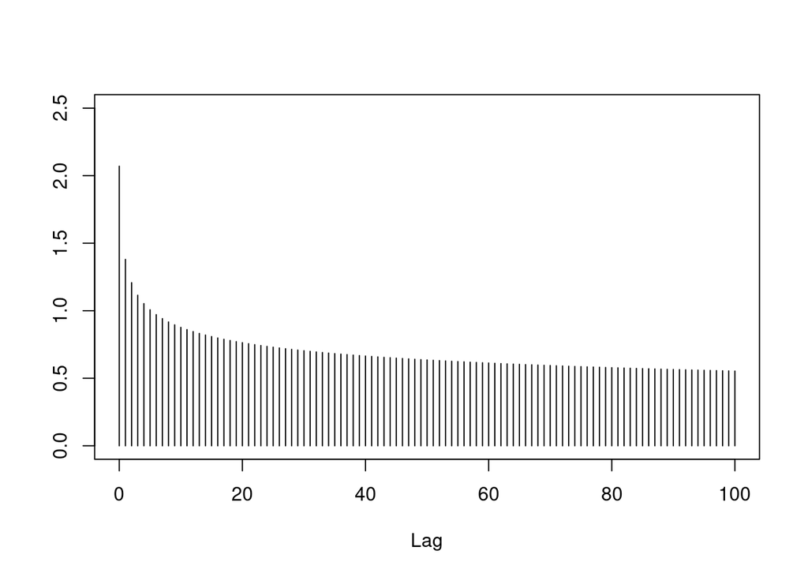

```r
lags <- seq(1,100)
d <- .4
gamma.lm <- gamma(1-2*d)/(gamma(1-d))^2
for(i in 1:length(lags))
{
  gamma.new <- gamma.lm[i] * (i-1+d)/(i-d)
  gamma.lm <- c(gamma.lm,gamma.new)
}
plot(ts(gamma.lm,start=0),type="h",xlab="Lag",ylab="",ylim=c(0,2.5))
```

## Example 9.1.3. Geometric Decay

- Suppose that a time series has ACVF $\gamma (h) = O(r^{|h|})$ for $0 < r < 1$.
- The notation means the ACVF is bounded by a constant times that rate.
- So there is a *geometric*, or *exponential*, rate of decay for the ACVF.
- This holds for ARMA processes by Proposition 5.8.3.

## Example 9.1.4. MA($q$) Correlation

- Suppose the a time series has ACVF $\gamma (h)$ that is zero if $|h| > q$.
- Then this can be represented as an MA($q$) process.
- This is an example of a *q-dependent* process: $X_t$ and $X_{t-h}$ are independent for any $t$ when $|h| > q$.